# Auditory Distance Perception Study Power Analysis

Lucas Gonzalez - Damian Payo - Manuel Eguia

21/7/2023

## Abstract

The analysis of results obtained from PAD experiment in June and July 2023 in room 27 of the National University of Quilmes is presented.

Two experiments were carried out. In experiment 1(a), 23 subjects participated (16 males, 6 females, and 1 non-binary) with ages ranging from 19 to 60 years (mean = 29, standard deviation = 9.69).

Experiment 1(b), involved 22 subjects (14 males, and 8 females) aged 19 to 63 years (mean = 34.36, standard deviation = 12.45).

## Data Loading

The data for experiment 1(a) are in the **Data_1k** folder. There are 69 .csv files corresponding to each condition/block for each subject.  
- “nsub” is the ID given to the subject  
- “dist_log” corresponds to the actual distance of the sound stimulus. It can contain 12 values.  
- “resp_log” is the subject’s response to the stimulus  
- “bloque” is not the actual data of the block order. It will be corrected later.

## Labeling

```r
# Corregimos la columna de condicion con una etiqueta mas legible
# WW -> Sin filtro
# LL -> Filtro pasa-bajo
# HH -> Filtro pasa-alto
data$condicion[data$condicion==0] <- "WW"
data$condicion[data$condicion==1] <- "LL"
data$condicion[data$condicion==2] <- "HH"

orden_bloques <- read.csv("./orden_bloques.csv")
data <- merge(x=orden_bloques,y=data,
                             by=c("nsub","condicion"))

# Erase redundant columns
data <- data[, !names(data) %in% c("bloque","altura")]

rm(orden_bloques)
```

## Subject dismissal

Before the evaluation, subjects were asked to complete a form with demographic information. Subject number 3 expressed hearing impairment in one ear, so we decided to exclude his data from the analysis.

## Log-Log Distance-Responses

We apply logarithms to the response and distance observations in order to make linear regressions between the variables and obtain a slope indicating distance compression

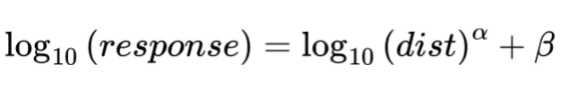

## Outlier Detection and Removal by Response

We applied the *Minimum Covariance Determinant* criteria to detect multivariate outliers.

We eliminated 408 observations from the total of 4860 with this method.

## Linear Regressions

We performed a linear regression for each condition per subject. We generate a new tibble containing a slope value for each condition per subject (nsub).

If slope is 1, it means that the compression ratio is 1 to 1, it means that there is no compression. If it is higher than 1, it means that there is expansion. If it is less than 1, it means that there is distance compression.

In addition, all the residuals (distance to linear regression) are put together in a vector (sresids). Finally, a variable is added with the order of the blocks by appearance during the experiment (order).

### Observation of normality in residuals

We plotted a histogram and qqplot with the residuals of the linear regression performed for each subject.

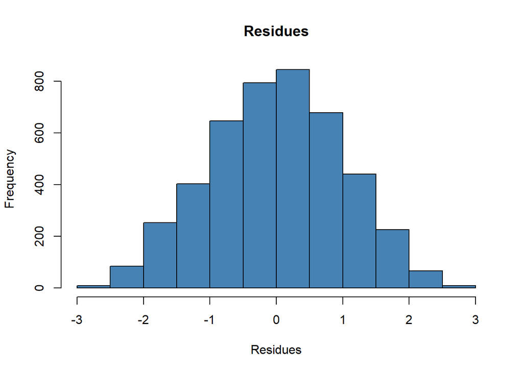

```r
# Histogram & QQ Plot
hist(sresids, col='steelblue', main='Residues',xlab="Residues")
```

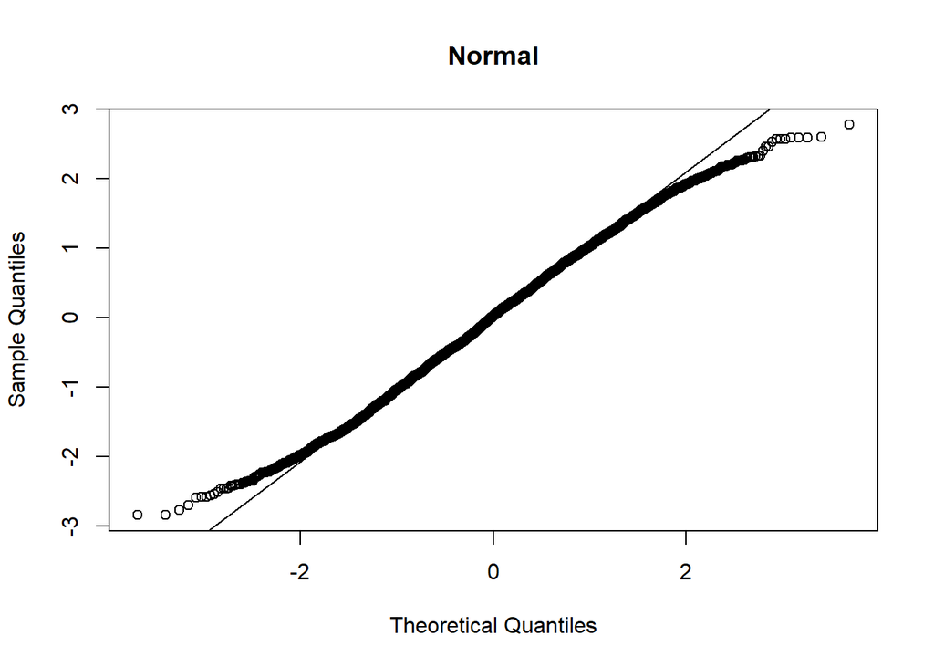

```r
qqnorm(sresids, main='Normal')
qqline(sresids)
```

```r
#qqPlot(sresids)
```

### Intrasubject residuals normality test

We performed an analysis of the normality of the intrasubject residuals with the Shapiro.Wilk method. The study compares subjects (nsubs) according to condition, reporting which ones do not allow us to approve the Null Hypothesis (H0) that residuals come from a normal distribution.

```r
normality_test <- data_clean %>%
  group_by(nsub, condicion) %>%
  summarise(statistic = shapiro.test(res)$statistic,
            p.value = shapiro.test(res)$p.value)

normality_test%>%subset(p.value<0.05)
```

```
## # A tibble: 5 × 4
## # Groups:   nsub [5]
##    nsub condicion statistic p.value
##   <int> <chr>         <dbl>   <dbl>
## 1    18 LL            0.887 0.00480
## 2    23 LL            0.924 0.0273
## 3    31 WW            0.926 0.0186
## 4    40 HH            0.898 0.0105
## 5    51 WW            0.930 0.0278
```

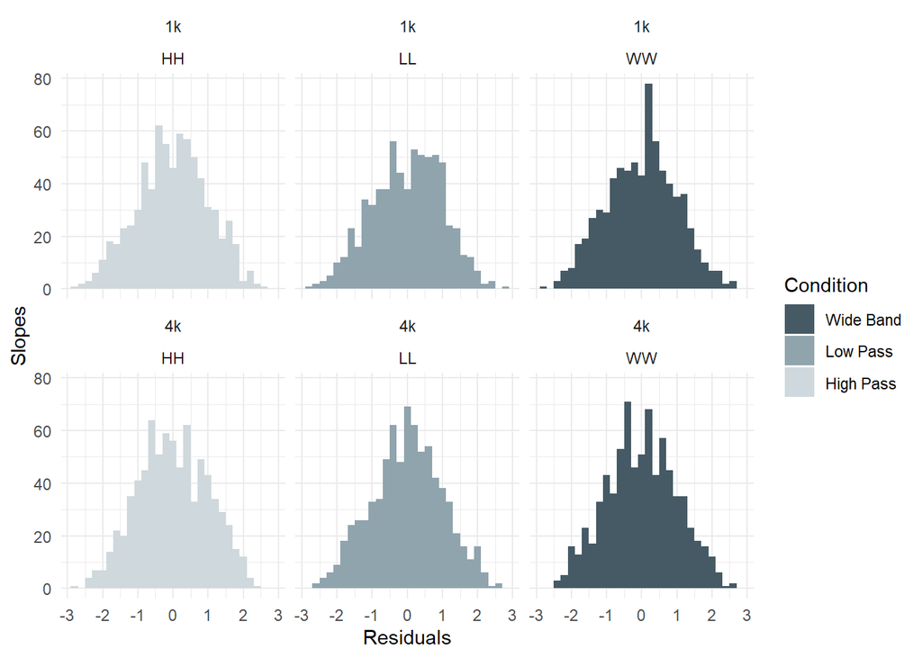

```r
## residuos ploteados en dos ejes, para poder ver la variabilidad por
## distancia por condicion por frecuencia.6 figuras en total
cols <- c("#455A64", "#90A4AE", "#CFD8DC" )

ggplot(data_clean, aes(x=res, fill=condicion))+
  geom_histogram(binwidth = 0.2)+
  scale_fill_manual(values = cols,
                    limits = c('WW', 'LL', 'HH'),
                   labels = c('Wide Band', 'Low Pass', 'High Pass')) +
  labs(y='Slopes', x="Residuals", fill="Condition")+
  facet_wrap(~freq+condicion, labeller = "label_value")+
  #label_value(labels= c('Wide Band', 'Low Pass', 'High Pass'))+
  theme_minimal()
```

```r
#ggplot(data_clean, aes(x=dist_log, y=res, color=condicion))+
#  geom_point()+
#  geom_hline(yintercept = 0)+
#  facet_wrap(~freq+condicion)+
#  theme_minimal()
```

### Outliers by Slopes and Incomplete subjects filtering

We applied the MAD (robust median absolute deviation) criterion to eliminate univariate outliers corresponding to the slopes.

Then we eliminate from the table the subjects without an observation for each condition.

```r
slope_1k_WW <- data_slopes %>% filter(freq=="1k", condicion=="WW")
slope_1k_LL <- data_slopes %>% filter(freq=="1k", condicion=="LL")
slope_1k_HH <- data_slopes %>% filter(freq=="1k", condicion=="HH")

slope_4k_WW <- data_slopes %>% filter(freq=="4k", condicion=="WW")
slope_4k_LL <- data_slopes %>% filter(freq=="4k", condicion=="LL")
slope_4k_HH <- data_slopes %>% filter(freq=="4k", condicion=="HH")

# 1k
outliers <-outliers_mad(slope_1k_WW$slope)
#outliers$limits[2]
slope_1k_WW<- slope_1k_WW[slope_1k_WW$slope<outliers$limits[2],]

outliers <-outliers_mad(slope_1k_LL$slope)
#outliers$limits[2]
slope_1k_LL<- slope_1k_LL[slope_1k_LL$slope<outliers$limits[2],]

outliers <-outliers_mad(slope_1k_HH$slope)
#outliers$limits[2]
slope_1k_HH<- slope_1k_HH[slope_1k_HH$slope<outliers$limits[2],]

# 4k
outliers <-outliers_mad(slope_4k_WW$slope)
#outliers$limits[2]
slope_4k_WW<- slope_4k_WW[slope_4k_WW$slope<outliers$limits[2],]

outliers <-outliers_mad(slope_4k_LL$slope)
#outliers$limits[2]
slope_4k_LL<- slope_4k_LL[slope_4k_LL$slope<outliers$limits[2],]

outliers <-outliers_mad(slope_4k_HH$slope)
#outliers$limits[2]
slope_4k_HH<- slope_4k_HH[slope_4k_HH$slope<outliers$limits[2],]

data_slopes_clean <- (rbind(slope_1k_HH,slope_1k_LL,slope_1k_WW,
                            slope_4k_HH,slope_4k_LL,slope_4k_WW))

count_conditions <- data_slopes_clean %>%
  group_by(nsub) %>%
  summarise(n = n())
drops <- count_conditions %>% subset(n!=3)

data_slopes_clean <- data_slopes_clean[!(data_slopes_clean$nsub%in%
                                                 drops$nsub), ]

data_clean <- data_clean[!(data_clean$nsub%in%
                             drops$nsub), ]

rm(count_conditions, outliers)
rm(slope_1k_HH, slope_1k_LL,slope_1k_WW,
   slope_4k_HH,slope_4k_LL,slope_4k_WW)
```

### Normality Test Slopes

```r
normality_slopes <- data_slopes_clean %>%
  group_by(freq, condicion) %>%
  summarise(statistic = shapiro.test(slope)$statistic,
            p.value = shapiro.test(slope)$p.value,
            normality=(p.value>0.05))

normality_slopes
```

```
## # A tibble: 6 × 5
## # Groups:   freq [2]
##   freq  condicion statistic p.value normality
##   <chr> <chr>         <dbl>   <dbl> <lgl>
## 1 1k    HH            0.945  0.408  TRUE
## 2 1k    LL            0.855  0.0162 FALSE
## 3 1k    WW            0.880  0.0389 FALSE
## 4 4k    HH            0.975  0.841  TRUE
## 5 4k    LL            0.900  0.0354 FALSE
## 6 4k    WW            0.954  0.405  TRUE
```

## Slopes Boxplot

We plotted in a boxplot the total slopes per condition for 1kHz and for 4kHz, noting the degree of significance in the data.

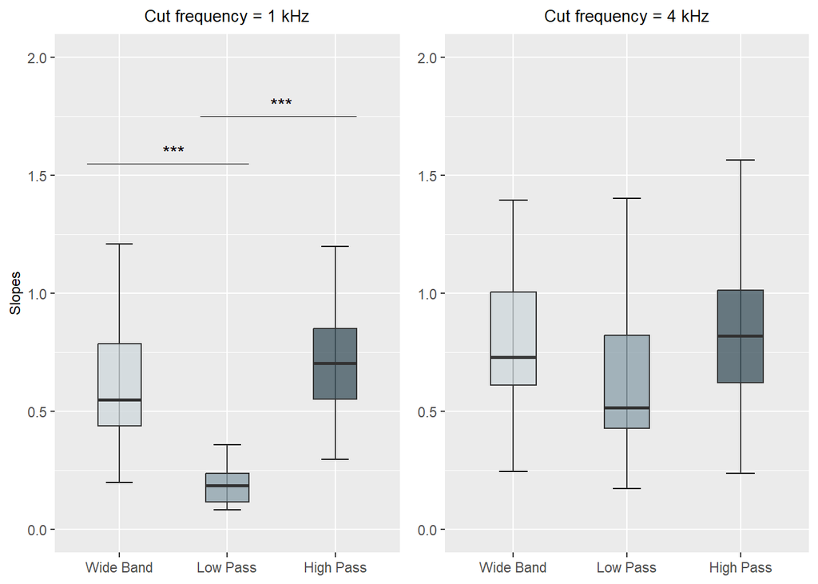

```r
cols <- c("#455A64", "#90A4AE", "#CFD8DC" )

plt_1k_slope <- ggplot(data_slopes_clean %>%
                         filter(freq=="1k"),
                       aes(x=condicion, y=slope, fill=condicion)) +
  stat_boxplot(geom = "errorbar",
               width = 0.25) +
  geom_boxplot(alpha=0.8, outlier.colour=NA, width = 0.4)+
  scale_x_discrete(limits = c('WW', 'LL', 'HH'),
                   labels = c('Wide Band', 'Low Pass', 'High Pass')) +
  scale_fill_manual(values = cols, guide='none') +
  scale_y_continuous(limits=c(0,2)) +
  labs(title="Cut frequency = 1 kHz", y='Slopes')+
  annotate("text", x = 1.5, y = 1.6,  label = "***", size = 4) +
  annotate("segment", x = 0.7, xend = 2.2, y = 1.55,
           yend = 1.55, colour = "black", size=.3, alpha=1,) +
  annotate("text", x = 2.5, y = 1.8,  label = "***", size = 4) +
  annotate("segment", x = 1.75, xend = 3.2, y = 1.75,
           yend = 1.75, colour = "black", size=.3, alpha=1,) +
  theme(axis.title.x = element_blank(),
        axis.title.y = element_text(size = 9),
        plot.title = element_text(size = 10, hjust = 0.5))

plt_4k_slope <- ggplot(data_slopes_clean %>%
                         filter(freq=="4k" & slope < 1.6),
                       aes(x=condicion, y=slope, fill=condicion)) +
  stat_boxplot(geom = "errorbar",
               width = 0.25) +
  geom_boxplot(alpha = 0.8, outlier.colour=NA, width = 0.4)+
  scale_x_discrete(limits = c('WW', 'LL', 'HH'),
                   labels = c('Wide Band', 'Low Pass', 'High Pass')) +
  scale_fill_manual(values = cols, guide='none') +
  scale_y_continuous(limits=c(0,2)) +
  labs(title="Cut frequency = 4 kHz")+
  theme(axis.title.x = element_blank(),
        axis.title.y = element_blank(),
        plot.title = element_text(size = 10, hjust = 0.5))

ggarrange(plt_1k_slope,plt_4k_slope, common.legend = TRUE)
```

### Regressions Plot

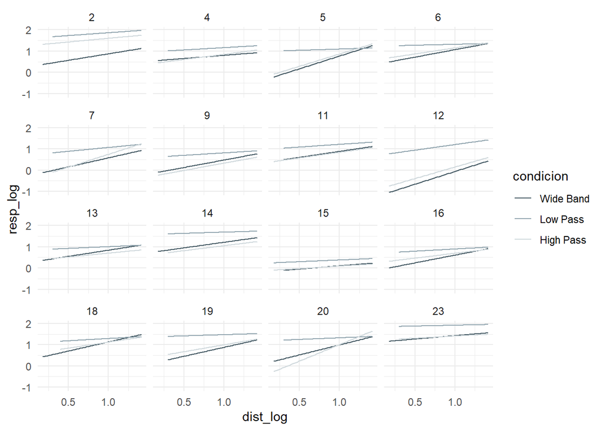

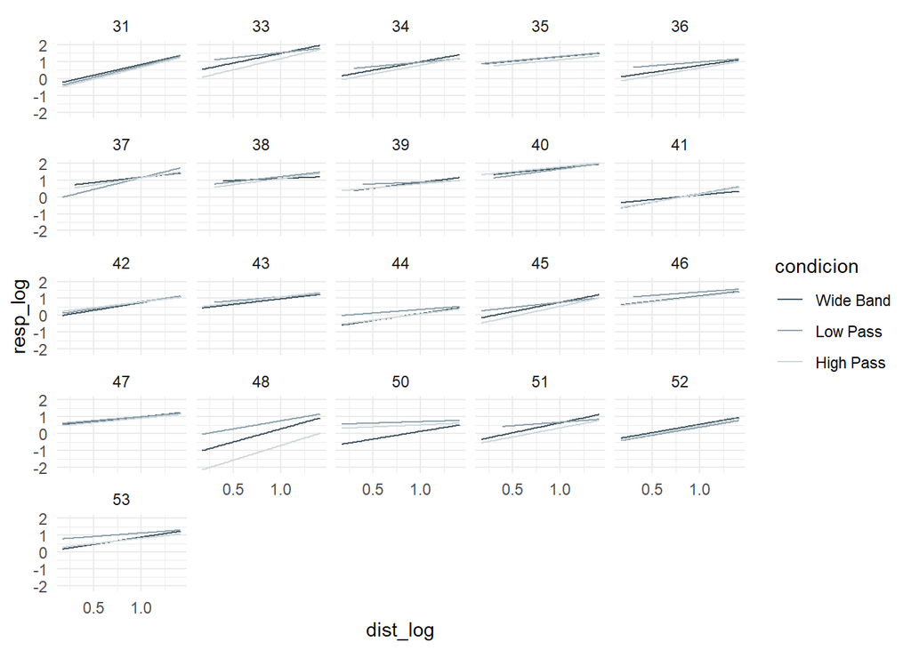

### 1K Data_prom tibble with means and std per condition

```r
cols <- c("#455A64", "#90A4AE", "#CFD8DC" )
data_prom <- data_clean %>% filter(freq == '1k') %>%
  group_by(condicion, dist_log) %>%
  summarise(dist_log,
            resp_log,
            prom_log = mean(resp_log),
            sd_log = sd(resp_log),
            std_log = std.error(resp_log))
```

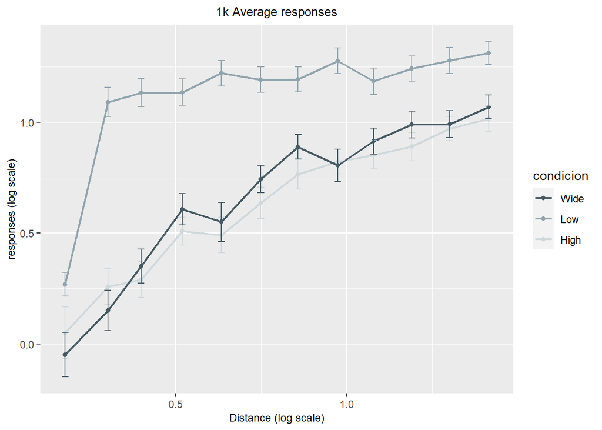

```r
ggplot(data_prom,
       aes(x=dist_log, y=prom_log,
           color = condicion)) +
  geom_point() +
  geom_line(linewidth = 0.8) +
  scale_color_manual(values = cols,
                    limits = c('WW', 'LL', 'HH'),
                    labels = c('Wide', 'Low', 'High')) +
  geom_errorbar(aes(ymin=prom_log-std_log,
                    ymax=prom_log+std_log),
                width = 0.02) +
  # facet_grid(rows = vars(ID)) +
  labs(title = "1k Average responses", x='Distance (log scale)', y='responses (log scale)') +
  theme(axis.title.x = element_text(size = 9),
        axis.title.y = element_text(size = 9),
        plot.title = element_text(size = 10, hjust = 0.5))
```

### 4K Data_prom tibble with means and std per condition

```r
cols <- c("#455A64", "#90A4AE", "#CFD8DC" )
data_prom <- data_clean %>% filter(freq == '4k') %>%
  group_by(condicion, dist_log) %>%
  summarise(dist_log,
            resp_log,
            prom_log = mean(resp_log),
            sd_log = sd(resp_log),
            std_log = std.error(resp_log))
```

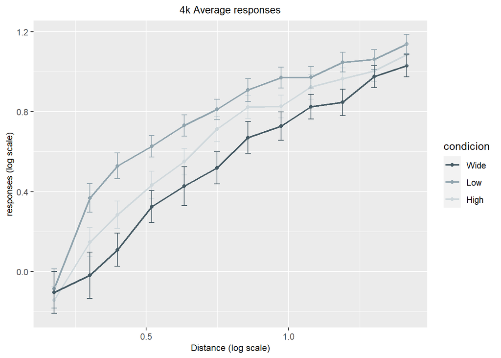

```r
ggplot(data_prom,
       aes(x=dist_log, y=prom_log,
           color = condicion)) +
  geom_point() +
  geom_line(linewidth = 0.8) +
  scale_color_manual(values = cols,
                    limits = c('WW', 'LL', 'HH'),
                    labels = c('Wide', 'Low', 'High')) +
  geom_errorbar(aes(ymin=prom_log-std_log,
                    ymax=prom_log+std_log),
                width = 0.02) +
  # facet_grid(rows = vars(ID)) +
  labs(title = "4k Average responses", x='Distance (log scale)', y='responses (log scale)') +
  theme(axis.title.x = element_text(size = 9),
        axis.title.y = element_text(size = 9),
        plot.title = element_text(size = 10, hjust = 0.5))
```

## Mixed Design Model

This analysis allows to evaluate the variation of slopes between intrasubject conditions.

[Reference](https://www.youtube.com/watch?v=AWInLxpiZuA)

### One way Anova with reapeated measures for Freq=1k

```r
lmer.1k <- lmer(slope ~ condicion + (1|nsub),
    data = data_slopes_clean %>% filter(freq=="1k"))
summary(lmer.1k)
```

```
## Linear mixed model fit by REML. t-tests use Satterthwaite's method [
## lmerModLmerTest]
## Formula: slope ~ condicion + (1 | nsub)
##    Data: data_slopes_clean %>% filter(freq == "1k")
##
## REML criterion at convergence: 13.4
##
## Scaled residuals:
##      Min       1Q   Median       3Q      Max
## -1.48589 -0.43771 -0.05404  0.49978  3.04146
##
## Random effects:
##  Groups   Name        Variance Std.Dev.
##  nsub     (Intercept) 0.03714  0.1927
##  Residual             0.04272  0.2067
## Number of obs: 48, groups:  nsub, 16
##
## Fixed effects:
##             Estimate Std. Error       df t value Pr(>|t|)
## (Intercept)  0.70126    0.07065 31.41371   9.926 3.32e-11 ***
## condicionLL -0.49689    0.07308 30.00000  -6.800 1.53e-07 ***
## condicionWW -0.04214    0.07308 30.00000  -0.577    0.568
## ---
## Signif. codes:  0 '***' 0.001 '**' 0.01 '*' 0.05 '.' 0.1 ' ' 1
##
## Correlation of Fixed Effects:
##             (Intr) cndcLL
## condicionLL -0.517
## condicionWW -0.517  0.500
```

```r
anova(lmer.1k)
```

```
## Type III Analysis of Variance Table with Satterthwaite's method
##           Sum Sq Mean Sq NumDF DenDF F value    Pr(>F)
## condicion 2.4292  1.2146     2    30  28.431 1.187e-07 ***
## ---
## Signif. codes:  0 '***' 0.001 '**' 0.01 '*' 0.05 '.' 0.1 ' ' 1
```

```r
##partial eta sq
effectsize::eta_squared(lmer.1k, partial = TRUE)
```

```
## # Effect Size for ANOVA (Type III)
##
## Parameter | Eta2 (partial) |       95% CI
## -----------------------------------------
## condicion |           0.65 | [0.47, 1.00]
##
## - One-sided CIs: upper bound fixed at [1.00].
```

```r
#Rsq
r.squaredGLMM(lmer.1k)
```

```
##           R2m      R2c
## [1,] 0.392918 0.675226
```

```r
emmeans(lmer.1k,
        list(pairwise ~ condicion),
        adjust="bonferroni")
```

```
## $`emmeans of condicion`
##  condicion emmean     SE   df lower.CL upper.CL
##  HH         0.701 0.0706 31.4   0.5573    0.845
##  LL         0.204 0.0706 31.4   0.0604    0.348
##  WW         0.659 0.0706 31.4   0.5151    0.803
##
## Degrees-of-freedom method: kenward-roger
## Confidence level used: 0.95
##
## $`pairwise differences of condicion`
##  1       estimate     SE df t.ratio p.value
##  HH - LL   0.4969 0.0731 30   6.800  <.0001
##  HH - WW   0.0421 0.0731 30   0.577  1.0000
##  LL - WW  -0.4547 0.0731 30  -6.223  <.0001
##
## Degrees-of-freedom method: kenward-roger
## P value adjustment: bonferroni method for 3 tests
```

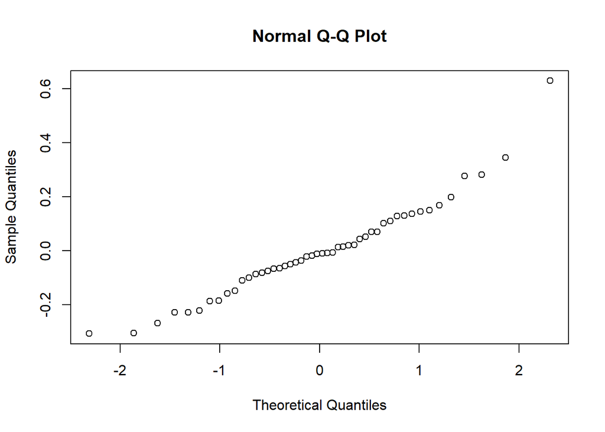

```r
qqnorm(resid(lmer.1k))
```

### One way Anova with reapeated measures LMER for Freq=4k

```r
lmer.4k <- lmer(slope ~ condicion + (1|nsub),
    data = data_slopes_clean %>% filter(freq=="4k"))

anova(lmer.4k)
```

```
## Type III Analysis of Variance Table with Satterthwaite's method
##            Sum Sq Mean Sq NumDF DenDF F value  Pr(>F)
## condicion 0.55733 0.27866     2    40  4.9139 0.01235 *
## ---
## Signif. codes:  0 '***' 0.001 '**' 0.01 '*' 0.05 '.' 0.1 ' ' 1
```

```r
##partial eta sq
effectsize::eta_squared(lmer.4k, partial = TRUE)
```

```
## # Effect Size for ANOVA (Type III)
##
## Parameter | Eta2 (partial) |       95% CI
## -----------------------------------------
## condicion |           0.20 | [0.03, 1.00]
##
## - One-sided CIs: upper bound fixed at [1.00].
```

```r
#Rsq
r.squaredGLMM(lmer.4k)
```

```
##             R2m       R2c
## [1,] 0.07408392 0.5326322
```

```r
emmeans(lmer.4k,
        list(pairwise ~ condicion),
        adjust="bonferroni")
```

```
## $`emmeans of condicion`
##  condicion emmean     SE   df lower.CL upper.CL
##  HH         0.839 0.0731 40.2    0.691    0.987
##  LL         0.647 0.0731 40.2    0.499    0.795
##  WW         0.854 0.0731 40.2    0.706    1.002
##
## Degrees-of-freedom method: kenward-roger
## Confidence level used: 0.95
##
## $`pairwise differences of condicion`
##  1       estimate     SE df t.ratio p.value
##  HH - LL    0.192 0.0735 40   2.607  0.0383
##  HH - WW   -0.015 0.0735 40  -0.205  1.0000
##  LL - WW   -0.207 0.0735 40  -2.811  0.0228
##
## Degrees-of-freedom method: kenward-roger
## P value adjustment: bonferroni method for 3 tests
```

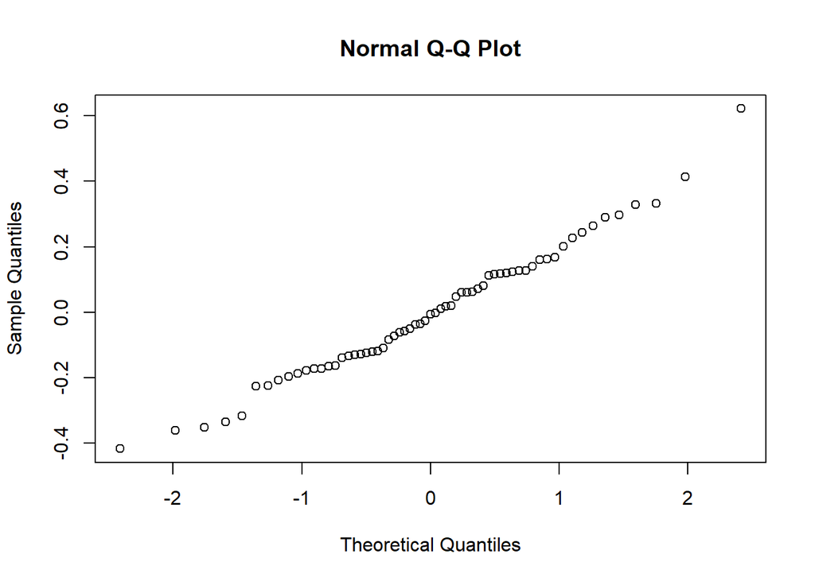

```r
qqnorm(resid(lmer.4k))
```

## Suplementary Analysis

### One way ANOVA (OLD)

This test was made only for comparison with the mixed design model.

In the ANOVA analysis without random effects, we show that the Condition factor is significant for determining slope variation in experiments performed with a cutoff frequency at 1kHz (p-value < 0.001), but not for studies performed with a cutoff frequency of 4kHz.

To see the degree of significance according to condition we performed pairwise comparisons between group levels with bonferroni correction for multiple testing (pairwise.t.test) which exposes the result in more detail.

```r
slopes_1k_clean <- data_slopes_clean%>%filter(freq=="1k")

lm.1k <-lm(slope~condicion,
               data=slopes_1k_clean)
# summary(lm.1k)

anova(lm.1k)
```

```
## Analysis of Variance Table
##
## Response: slope
##           Df Sum Sq Mean Sq F value    Pr(>F)
## condicion  2 2.4292 1.21461   15.21 8.993e-06 ***
## Residuals 45 3.5936 0.07986
## ---
## Signif. codes:  0 '***' 0.001 '**' 0.01 '*' 0.05 '.' 0.1 ' ' 1
```

```r
pairwise.t.test(slopes_1k_clean$slope,
                slopes_1k_clean$condicion,
                p.adjust.method = "bonferroni")
```

```
##
##  Pairwise comparisons using t tests with pooled SD
##
## data:  slopes_1k_clean$slope and slopes_1k_clean$condicion
##
##    HH      LL
## LL 3e-05   -
## WW 1.00000 0.00012
##
## P value adjustment method: bonferroni
```

```r
#rm(slopes_1k_clean)
```

```r
slopes_4k_clean <- data_slopes_clean%>%filter(freq=="4k")

lm_4k <-lm(slope ~ condicion,
                data=slopes_4k_clean)
#summary(lm_4k)

anova(lm_4k)
```

```
## Analysis of Variance Table
##
## Response: slope
##           Df Sum Sq Mean Sq F value  Pr(>F)
## condicion  2 0.5573 0.27866  2.4804 0.09226 .
## Residuals 60 6.7409 0.11235
## ---
## Signif. codes:  0 '***' 0.001 '**' 0.01 '*' 0.05 '.' 0.1 ' ' 1
```

```r
pairwise.t.test(slopes_4k_clean$slope,
                slopes_4k_clean$condicion,
                p.adjust.method = "bonferroni")
```

```
##
##  Pairwise comparisons using t tests with pooled SD
##
## data:  slopes_4k_clean$slope and slopes_4k_clean$condicion
##
##    HH   LL
## LL 0.21 -
## WW 1.00 0.15
##
## P value adjustment method: bonferroni
```

```r
#rm(slopes_4k_clean)
```

### Adding Block-Order as factor to the model

#### Block-Order Boxplot

We performed an analysis of slopes by condition according to the order of occurrence of the stimuli during the experiment. This allows us to evaluate whether the compression of the slopes is related to the order of appearance.

It is possible to infer that responses tend to exhibit more compressed slopes in Low as this more advanced block is presented. However, this conditional is not expressed in the rest of conditions.

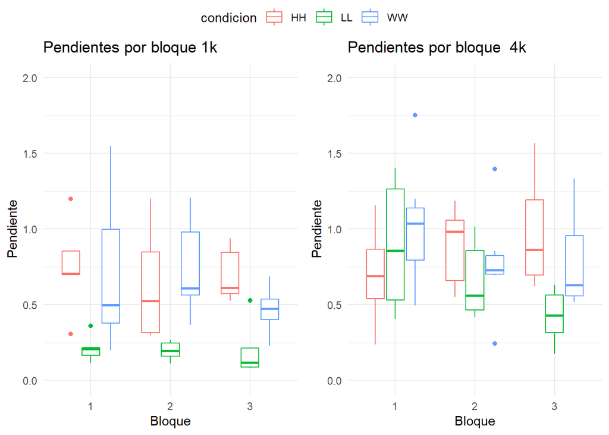

```r
plt_1k_per_block <- ggplot(slopes_1k_clean,
                           aes(x=as.character(orden_bloque),
                               y=slope,
                               color=condicion)) +
  geom_boxplot()+
  #geom_point(position = "jitter")+
  xlab("Bloque")+
  ylab("Pendiente")+
  labs(title="Pendientes por bloque 1k")+
  scale_y_continuous(limits=c(0,2)) +
  theme_minimal()

plt_4k_per_block <- ggplot(slopes_4k_clean,
                           aes(x=as.character(orden_bloque),
                               y=slope,color=condicion)) +
  geom_boxplot()+
  #geom_point(position = "jitter")+
  xlab("Bloque")+
  ylab("Pendiente")+
  labs(title="Pendientes por bloque  4k")+
  scale_y_continuous(limits=c(0,2)) +
  theme_minimal()

ggarrange(plt_1k_per_block,plt_4k_per_block, common.legend = TRUE)
```

### 1k Two factor Mixed design ANOVA

```r
# Fit a linear mixed-effects model with the
# interaction between "Order" and "condicion"
model_lmer_1k <- lmer(slope ~ condicion*as.factor(orden_bloque) + (1|nsub),
                   data = slopes_1k_clean)
# Get the summary of the model
summary(model_lmer_1k)
```

```
## Linear mixed model fit by REML. t-tests use Satterthwaite's method [
## lmerModLmerTest]
## Formula: slope ~ condicion * as.factor(orden_bloque) + (1 | nsub)
##    Data: slopes_1k_clean
##
## REML criterion at convergence: 23.5
##
## Scaled residuals:
##      Min       1Q   Median       3Q      Max
## -1.38821 -0.48000 -0.02973  0.44156  2.72661
##
## Random effects:
##  Groups   Name        Variance Std.Dev.
##  nsub     (Intercept) 0.03613  0.1901
##  Residual             0.04858  0.2204
## Number of obs: 48, groups:  nsub, 16
##
## Fixed effects:
##                                      Estimate Std. Error       df t value
## (Intercept)                           0.73484    0.11987 38.96111   6.130
## condicionLL                          -0.51850    0.16191 34.00019  -3.202
## condicionWW                          -0.01584    0.15604 34.80074  -0.102
## as.factor(orden_bloque)2             -0.07413    0.17125 33.69119  -0.433
## as.factor(orden_bloque)3             -0.03438    0.15103 34.88033  -0.228
## condicionLL:as.factor(orden_bloque)2  0.09251    0.24257 35.85585   0.381
## condicionWW:as.factor(orden_bloque)2  0.04197    0.24052 36.61482   0.174
## condicionLL:as.factor(orden_bloque)3 -0.02597    0.23743 37.19682  -0.109
## condicionWW:as.factor(orden_bloque)3 -0.15690    0.23904 37.11832  -0.656
##                                      Pr(>|t|)
## (Intercept)                          3.43e-07 ***
## condicionLL                           0.00296 **
## condicionWW                           0.91973
## as.factor(orden_bloque)2              0.66787
## as.factor(orden_bloque)3              0.82127
## condicionLL:as.factor(orden_bloque)2  0.70517
## condicionWW:as.factor(orden_bloque)2  0.86244
## condicionLL:as.factor(orden_bloque)3  0.91349
## condicionWW:as.factor(orden_bloque)3  0.51564
## ---
## Signif. codes:  0 '***' 0.001 '**' 0.01 '*' 0.05 '.' 0.1 ' ' 1
##
## Correlation of Fixed Effects:
##             (Intr) cndcLL cndcWW a.(_)2 a.(_)3 cLL:.(_)2 cWW:.(_)2 cLL:.(_)3
## condicionLL -0.677
## condicionWW -0.708  0.522
## as.fctr(_)2 -0.637  0.533  0.541
## as.fctr(_)3 -0.733  0.599  0.640  0.508
## cndLL:.(_)2  0.482 -0.735 -0.352 -0.770 -0.375
## cndWW:.(_)2  0.519 -0.384 -0.732 -0.789 -0.431  0.536
## cndLL:.(_)3  0.542 -0.778 -0.439 -0.379 -0.739  0.504     0.298
## cndWW:.(_)3  0.523 -0.377 -0.746 -0.341 -0.729  0.207     0.480     0.482
```

```r
anova(model_lmer_1k)
```

```
## Type III Analysis of Variance Table with Satterthwaite's method
##                                    Sum Sq Mean Sq NumDF  DenDF F value
## condicion                         2.30500 1.15250     2 25.178 23.7249
## as.factor(orden_bloque)           0.07310 0.03655     2 25.178  0.7524
## condicion:as.factor(orden_bloque) 0.04014 0.01003     4 36.622  0.2066
##                                      Pr(>F)
## condicion                         1.615e-06 ***
## as.factor(orden_bloque)              0.4816
## condicion:as.factor(orden_bloque)    0.9331
## ---
## Signif. codes:  0 '***' 0.001 '**' 0.01 '*' 0.05 '.' 0.1 ' ' 1
```

#### Post-hoc

```r
emmeans(model_lmer_1k,
        list(pairwise ~ condicion),
        adjust="bonferroni")
```

```
## NOTE: Results may be misleading due to involvement in interactions
```

```
## $`emmeans of condicion`
##  condicion emmean     SE   df lower.CL upper.CL
##  HH         0.699 0.0744 30.6   0.5469    0.850
##  LL         0.202 0.0730 29.8   0.0532    0.351
##  WW         0.645 0.0739 30.4   0.4938    0.795
##
## Results are averaged over the levels of: orden_bloque
## Degrees-of-freedom method: kenward-roger
## Confidence level used: 0.95
##
## $`pairwise differences of condicion`
##  1       estimate     SE   df t.ratio p.value
##  HH - LL   0.4963 0.0795 24.5   6.245  <.0001
##  HH - WW   0.0541 0.0801 24.5   0.676  1.0000
##  LL - WW  -0.4422 0.0792 24.5  -5.584  <.0001
##
## Results are averaged over the levels of: orden_bloque
## Degrees-of-freedom method: kenward-roger
## P value adjustment: bonferroni method for 3 tests
```

```r
emmeans(model_lmer_1k,
        list(pairwise ~ orden_bloque),
        adjust="bonferroni")
```

```
## NOTE: Results may be misleading due to involvement in interactions
```

```
## $`emmeans of orden_bloque`
##  orden_bloque emmean     SE   df lower.CL upper.CL
##             1  0.557 0.0730 29.8    0.408    0.706
##             2  0.527 0.0739 30.4    0.377    0.678
##             3  0.461 0.0744 30.6    0.310    0.613
##
## Results are averaged over the levels of: condicion
## Degrees-of-freedom method: kenward-roger
## Confidence level used: 0.95
##
## $`pairwise differences of orden_bloque`
##  1                             estimate     SE   df t.ratio p.value
##  orden_bloque1 - orden_bloque2   0.0293 0.0792 24.5   0.370  1.0000
##  orden_bloque1 - orden_bloque3   0.0953 0.0795 24.5   1.200  0.7254
##  orden_bloque2 - orden_bloque3   0.0660 0.0801 24.5   0.825  1.0000
##
## Results are averaged over the levels of: condicion
## Degrees-of-freedom method: kenward-roger
## P value adjustment: bonferroni method for 3 tests
```

### 4k Two factor Mixed design ANOVA

```r
# Fit a linear mixed-effects model with the
# interaction between "Order" and "condicion"
model_lmer_4k <- lmer(slope ~ condicion*as.factor(orden_bloque) + (1|nsub),
                   data = slopes_4k_clean)

# Get the summary of the model
summary(model_lmer_4k)
```

```
## Linear mixed model fit by REML. t-tests use Satterthwaite's method [
## lmerModLmerTest]
## Formula: slope ~ condicion * as.factor(orden_bloque) + (1 | nsub)
##    Data: slopes_4k_clean
##
## REML criterion at convergence: 34.8
##
## Scaled residuals:
##      Min       1Q   Median       3Q      Max
## -1.85285 -0.53643  0.04671  0.34701  1.84214
##
## Random effects:
##  Groups   Name        Variance Std.Dev.
##  nsub     (Intercept) 0.05174  0.2275
##  Residual             0.04943  0.2223
## Number of obs: 63, groups:  nsub, 21
##
## Fixed effects:
##                                      Estimate Std. Error      df t value
## (Intercept)                            0.7424     0.1014 53.4639   7.323
## condicionLL                            0.1659     0.1427 45.5296   1.162
## condicionWW                            0.2163     0.1375 46.2391   1.573
## as.factor(orden_bloque)2               0.1850     0.1375 46.2391   1.346
## as.factor(orden_bloque)3               0.1215     0.1427 45.5296   0.851
## condicionLL:as.factor(orden_bloque)2  -0.4747     0.2137 49.4182  -2.221
## condicionWW:as.factor(orden_bloque)2  -0.3746     0.2152 48.7963  -1.741
## condicionLL:as.factor(orden_bloque)3  -0.5739     0.2172 47.9554  -2.642
## condicionWW:as.factor(orden_bloque)3  -0.2547     0.2137 49.4182  -1.192
##                                      Pr(>|t|)
## (Intercept)                           1.3e-09 ***
## condicionLL                            0.2511
## condicionWW                            0.1225
## as.factor(orden_bloque)2               0.1850
## as.factor(orden_bloque)3               0.3990
## condicionLL:as.factor(orden_bloque)2   0.0309 *
## condicionWW:as.factor(orden_bloque)2   0.0880 .
## condicionLL:as.factor(orden_bloque)3   0.0111 *
## condicionWW:as.factor(orden_bloque)3   0.2390
## ---
## Signif. codes:  0 '***' 0.001 '**' 0.01 '*' 0.05 '.' 0.1 ' ' 1
##
## Correlation of Fixed Effects:
##             (Intr) cndcLL cndcWW a.(_)2 a.(_)3 cLL:.(_)2 cWW:.(_)2 cLL:.(_)3
## condicionLL -0.607
## condicionWW -0.635  0.454
## as.fctr(_)2 -0.635  0.522  0.566
## as.fctr(_)3 -0.607  0.519  0.522  0.454
## cndLL:.(_)2  0.489 -0.772 -0.394 -0.752 -0.370
## cndWW:.(_)2  0.462 -0.317 -0.739 -0.739 -0.317  0.487
## cndLL:.(_)3  0.442 -0.743 -0.316 -0.316 -0.743  0.501     0.174
## cndWW:.(_)3  0.489 -0.370 -0.752 -0.394 -0.772  0.298     0.487     0.501
```

```r
anova(model_lmer_4k)
```

```
## Type III Analysis of Variance Table with Satterthwaite's method
##                                    Sum Sq Mean Sq NumDF  DenDF F value  Pr(>F)
## condicion                         0.48092 0.24046     2 34.406  4.8642 0.01379
## as.factor(orden_bloque)           0.25277 0.12638     2 34.406  2.5566 0.09222
## condicion:as.factor(orden_bloque) 0.47064 0.11766     4 48.430  2.3801 0.06452
##
## condicion                         *
## as.factor(orden_bloque)           .
## condicion:as.factor(orden_bloque) .
## ---
## Signif. codes:  0 '***' 0.001 '**' 0.01 '*' 0.05 '.' 0.1 ' ' 1
```

#### Post-hoc

```r
emmeans(model_lmer_4k,
        list(pairwise ~ condicion),
        adjust="bonferroni")
```

```
## NOTE: Results may be misleading due to involvement in interactions
```

```
## $`emmeans of condicion`
##  condicion emmean     SE   df lower.CL upper.CL
##  HH         0.845 0.0698 37.2    0.703    0.986
##  LL         0.661 0.0698 37.2    0.520    0.802
##  WW         0.851 0.0698 37.2    0.710    0.993
##
## Results are averaged over the levels of: orden_bloque
## Degrees-of-freedom method: kenward-roger
## Confidence level used: 0.95
##
## $`pairwise differences of condicion`
##  1       estimate     SE   df t.ratio p.value
##  HH - LL  0.18358 0.0692 34.3   2.652  0.0361
##  HH - WW -0.00656 0.0692 34.3  -0.095  1.0000
##  LL - WW -0.19013 0.0692 34.3  -2.747  0.0286
##
## Results are averaged over the levels of: orden_bloque
## Degrees-of-freedom method: kenward-roger
## P value adjustment: bonferroni method for 3 tests
```

```r
emmeans(model_lmer_4k,
        list(pairwise ~ orden_bloque),
        adjust="bonferroni")
```

```
## NOTE: Results may be misleading due to involvement in interactions
```

```
## $`emmeans of orden_bloque`
##  orden_bloque emmean     SE   df lower.CL upper.CL
##             1  0.870 0.0698 37.2    0.729    1.011
##             2  0.772 0.0698 37.2    0.630    0.913
##             3  0.715 0.0698 37.2    0.574    0.857
##
## Results are averaged over the levels of: condicion
## Degrees-of-freedom method: kenward-roger
## Confidence level used: 0.95
##
## $`pairwise differences of orden_bloque`
##  1                             estimate     SE   df t.ratio p.value
##  orden_bloque1 - orden_bloque2   0.0981 0.0692 34.3   1.417  0.4969
##  orden_bloque1 - orden_bloque3   0.1547 0.0692 34.3   2.234  0.0963
##  orden_bloque2 - orden_bloque3   0.0566 0.0692 34.3   0.818  1.0000
##
## Results are averaged over the levels of: condicion
## Degrees-of-freedom method: kenward-roger
## P value adjustment: bonferroni method for 3 tests
```

### Conclusión sobre agregar un factor de orden

Si bien este tipo de test no nos permite sacar una conclusión clara sobre si el orden de los bloques afecta, este no encuentra un efecto significativo en el factor tanto para el filtro con corte en 1k como en 4k.